# Estimation of Iranian Real Estate Units Sales Prices

C. Curaba, Y. Martínez Jiménez, E. Stefanel

2023-01-24

## Assignment statement

The [**Residential Building Data Set**](https://archive.ics.uci.edu/ml/datasets/Residential+Building+Data+Set) has been donated by PhD. Mohammad H. Rafiei from The Ohio State University, Columbus, and includes $372$ observations about real estate single-family residential apartments in Tehran, Iran. In particular, for each apartment are reported $8$ project physical and financial variables and $19$ economic variables and indices. This $19$ features are reported in $5$ time lags[^1], leading a total of $103$ possible explanatory variables for the two output variables, that are `ConstructionCosts` and `SalesPrices`.

The aim of the present project is to build an efficient pipeline to estimate the `SalesPrices`, observing the explanatory variables. Following the Occam’s razor principle (*pluralitas non est ponenda sine necessitate*, “plurality should not be posited without necessity”), our aim is to get an easily interpretative model, rather than a very complex one but difficult to understand. In order to do that, we start by analyzing the dataset and performing some feature engineering. We then study some possible statistical model for the estimation. Finally, we conclude by summarizing the results and proposing some possible future improvement.

## Data analysis

The first thing we do after importing the dataset from the original repository is to rename the columns in a more friendly and informative way. This is done by following the description of the features in the `Description` sheet of the Excel file from the `https://archive.ics.uci.edu` archive.

|  | StartYear | StartQuarter | CompletionYear | CompletionQuarter | BuildingZIPCode | BuildingFloorArea | LotArea | TotEstConstructionCost | EstConstructionCost | EstConstructionCostBaseYear | ConstructionDuration | PriceAtBeginning | BuildingPermitsNo_1 | BSI_1 | WPI_1 | BuildingPermitsFloorArea_1 | CumulativeLiquidity_1 | PrivateSectorInvestment_1 | LandPriceIndexBaseYear_1 | LoansExtendedNo_1 | LoansExtendedAmount_1 | InterestRate_1 | ConstructionCostAtCompletion_1 | ConstructionCostAtBeginning_1 | OfficialExcangeRateUSD_1 | StreetMarketExcangeRateUSD_1 | CPIBaseYear_1 | CPIFornituresBaseYear_1 | StockMarketIndex_1 | … |
| --- | --- | --- | --- | --- | --- | --- | --- | --- | --- | --- | --- | --- | --- | --- | --- | --- | --- | --- | --- | --- | --- | --- | --- | --- | --- | --- | --- | --- | --- | --- |
| 1 | 81 | 1 | 85 | 1 | 1 | 3150 | 920 | 598.5 | 190 | 1010.84 | 16 | 1200 | 6713.00 | 56.2 | 61.52 | 6.11 | 320957.30 | 3485.8 | 64.5 | 239.50 | 12456.6 | 15 | 797.3 | 809.8 | 1755.00 | 8003 | 67.81 | 63.25 | 3758.77 | … |
| 2 | 84 | 1 | 89 | 4 | 1 | 7600 | 1140 | 3040.0 | 400 | 963.81 | 23 | 2900 | 3152.00 | 106.0 | 103.03 | 3.15 | 685697.50 | 3526.1 | 105.5 | 208.80 | 17584.3 | 15 | 1408.4 | 1473.5 | 8842.18 | 8864 | 105.52 | 105.32 | 12113.01 | … |
| 3 | 78 | 1 | 81 | 4 | 1 | 4800 | 840 | 480.0 | 100 | 689.84 | 15 | 630 | 1627.00 | 41.0 | 41.25 | 1.74 | 160401.50 | 1217.5 | 34.4 | 285.80 | 6489.1 | 15 | 614.0 | 608.2 | 1755.00 | 7773 | 45.91 | 38.34 | 1537.96 | … |
| 4 | 72 | 2 | 73 | 2 | 1 | 685 | 202 | 13.7 | 20 | 459.54 | 4 | 140 | 2580.93 | 12.1 | 10.03 | 1.24 | 38193.64 | 287.2 | 13.6 | 17.03 | 154.4 | 12 | 183.6 | 211.1 | 1612.95 | 1649 | 11.62 | 10.06 | 392.96 | … |
| 5 | 87 | 1 | 90 | 2 | 1 | 3000 | 800 | 1230.0 | 410 | 631.91 | 13 | 5000 | 6790.00 | 203.8 | 162.84 | 6.46 | 1640293.00 | 10855.3 | 229.3 | 393.30 | 69444.8 | 11 | 2738.8 | 3148.0 | 9248.40 | 9380 | 158.63 | 169.50 | 10082.00 | … |
| 6 | 87 | 1 | 90 | 1 | 1 | 2500 | 640 | 1050.0 | 420 | 647.32 | 12 | 4800 | 6790.00 | 203.8 | 162.84 | 6.46 | 1640293.00 | 10855.3 | 229.3 | 393.30 | 69444.8 | 11 | 2738.8 | 3148.0 | 9248.40 | 9380 | 158.63 | 169.50 | 10082.00 | … |

We are now going to list all the dataframe columns and explain their meanings:

- `StartYear`, `StartQuarter`, `CompletionYear` and `CompletionQuarter` are temporal references about the Building project. Only the last two digits of the years are reported, so we will add $1300$ to each year (keeping in mind that dates are referring to the Persian calendar);
- `BuildingZIPCode` is the ZIP Code where the Building is located, `BuildingFloorArea` and `LotArea` are surfaces values, measured in square meters, referring to the construction lot. `TotEstConstructionCost`, `EstConstructionCost` and `EstConstructionCostBaseYear` are total construction cost, in ten thousands Rial (Iranian currency), actual and estimated at the beginning of the project (the last is also adjusted to inflation at the year $1383$). `ConstructionDuration` is the duration, in quarters, of the constructions, and `PriceAtBeginning` is the specific square root price before the construction start. This are Building-specific features that do not change during the construction period;
- There is then a set of $19$ features that are measured at five regular intervals from the construction starting date and the completion date. Each of them will then be present in the dataframe for a total of five times. `BuildingPermitsNo` is the number of building permits issued, `BSI` and `WPI` are Building Services Index and Wholesale Price Index, `BuildingPermitsFloorArea` is the total floor areas, in square meters, of building permits issued by the city. `CumulativeLiquidity` represents, in ten millions of Rial, how rapidly different types of assets can be changed to cash, `PrivateSectorInvestment` is the sector investment in new buildings, `LandPriceIndexBaseYear` is the square root price in year $1383$. The columns `LoansExtendedNo`, `LoansExtendedAmount` and `InterestRate` refers to extended loans during the lag. `ConstructionCostAtCompletion` and `ConstructionCostAtBeginning` are average construction cost of buildings by private sector at the time of completion and beginning of construction. `OfficialExcangeRateUSD` and `StreetMarketExcangeRateUSD` are official and nonofficial (street market) exchange rate with respect to dollars. `CPIBaseYear` and `CPIFornituresBaseYear` are respectively total Consumer Price Index and CPI only related to furniture. `StockMarketIndex` represent the payback condition of investment in stock market, `CityPopulation` the population of the city and `GoldPriceOnce` gold price, in Rial, per ounce;
- `SalesPrices` and `ConstructionCosts` are the two response variables, indicating the final selling price of the estate and total construction costs, respectively. Both measures use $10000$ Rial as measure unit.

Now that we understand what the individual columns refer to, we can analyze which variables are qualitative (ordered or not), and which are quantitative (discrete or continuous).

The first thing that we note is that there are no qualitative columns in the dataset. The only columns that could be interpreted as factor column are the `StartQuarter` and `CompletionQuarter` ones, where only value from $1$ to $4$ are possible, and `BuildingZIPCode` with values from $1$ to $20$. All the other variables are continuous quantitative measures.

Next, we proceed to check whether any records contain any missing columns. If so, we will decide how to handle it.

```
## [1] "There are no columns with missing values!"
```

Fortunately, there are no columns where missing values occur. This can be because a preventive data cleaning has been done by the person who uploaded the dataframe on the public repository, or because the data collection method was meticulous and error-free. We lean toward the first of the two options.

We note that we could implode years and quarters information into a single value, one for starting date and one for completion date. This is done by simply adding $.25$ to each year value for each ended quarter of the current year at the start (or completion) of the project. In this way, the first quarter of the $x$ year will be $x.00$, the second quarter will be $x.25$, and so on.

We now analyze the distribution of the response variable in the dataset. Plotting the histogram, and analyzing variable data summary can help us.

```
##    Min. 1st Qu.  Median    Mean 3rd Qu.    Max.
##    50.0   577.5  1000.0  1387.4  1700.0  6800.0
```

```
## [1] 1206.083
```

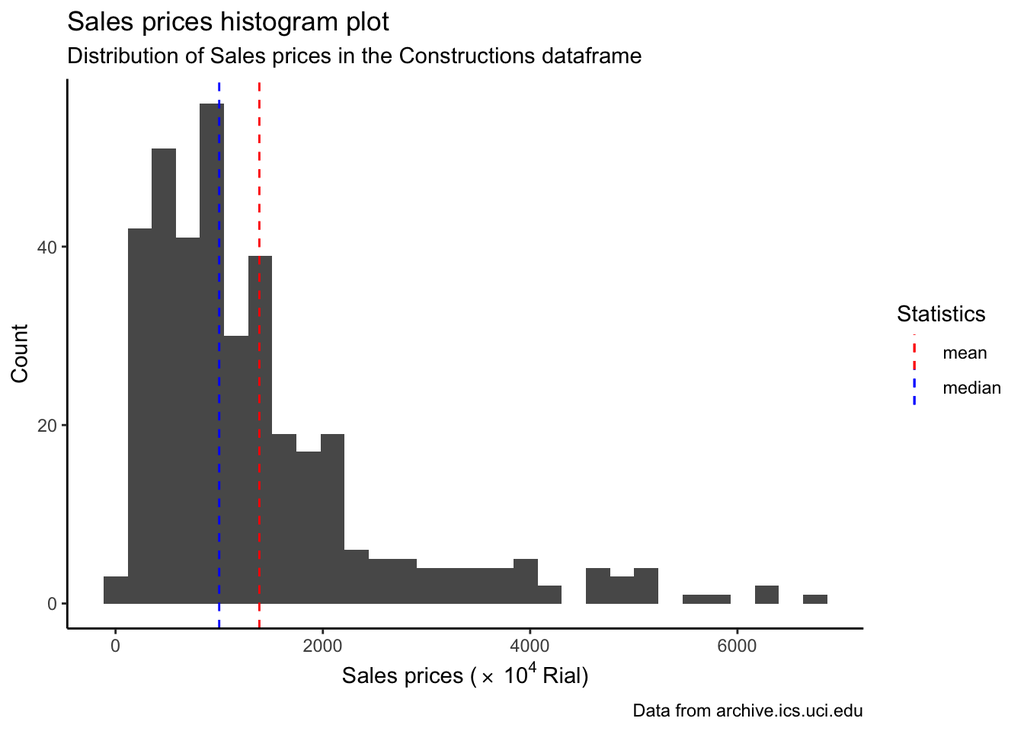

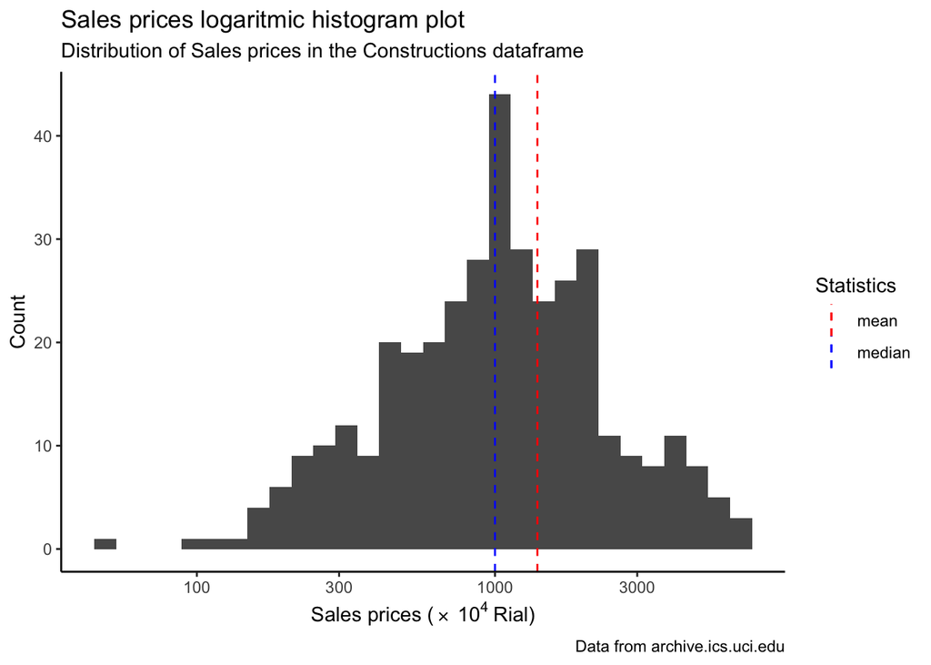

We see that the distribution of the log-scaled `SalesPrices` can somehow remember a normal distribution.

It is also very useful to study possible correlations in the dataset between the response variable and the independent variables.

To do so, let’s analyze the top three positively and top three negatively correlated columns with `SalesPrices`, with relative correlations:

```
##    PriceAtBeginning EstConstructionCost       CPIBaseYear_4
##           0.9764315           0.7849861           0.6170122
```

```
##  InterestRate_2  InterestRate_1 BuildingZIPCode
##      -0.3691482      -0.4080055      -0.4350808
```

It is straightforward to note that `PriceAtBeginning` has a really high correlation with the response variable. Recall that `PriceAtBeginning` column is the price of the building unit at the beginning of the project. The relation is evident if we draw the scatter plot of the two variables.

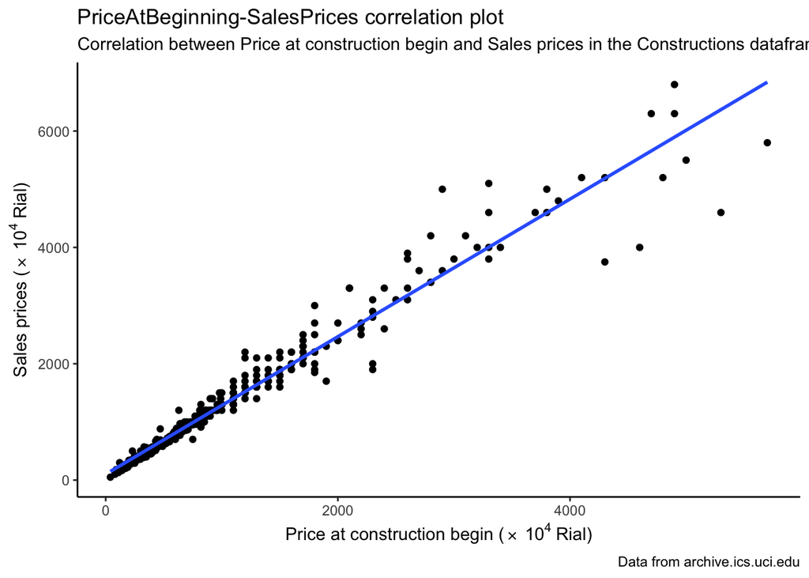

As for negative correlations, `BuildingZIPCode` reports a $-0.44$ index of correlation. This may suggest that high-ZIP code buildings report minor final `SalesPrices`, adjusted for the others variables.

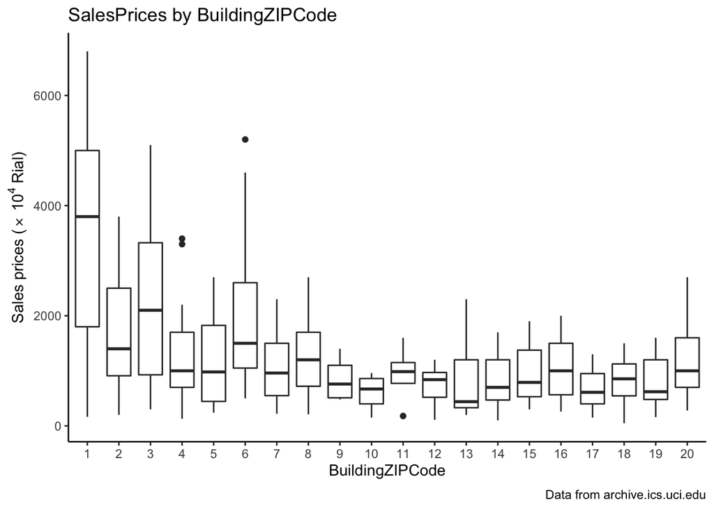

With a visual inspection of the relation, we note that some ZIP codes are more influential than others in predicting the `SalesPrices` response. We decide to summary `BuildingZIPCode` information into four main groups: ZIP Codes number $1$, $3$, $6$ and other ZIP Codes (named $21$).

|  | StartYear | CompletionYear | BuildingZIPCode | BuildingFloorArea | LotArea | TotEstConstructionCost | EstConstructionCost | EstConstructionCostBaseYear | ConstructionDuration | PriceAtBeginning | BuildingPermitsNo_1 | BSI_1 | WPI_1 | BuildingPermitsFloorArea_1 | CumulativeLiquidity_1 | PrivateSectorInvestment_1 | LandPriceIndexBaseYear_1 | LoansExtendedNo_1 | LoansExtendedAmount_1 | InterestRate_1 | ConstructionCostAtCompletion_1 | ConstructionCostAtBeginning_1 | OfficialExcangeRateUSD_1 | StreetMarketExcangeRateUSD_1 | CPIBaseYear_1 | CPIFornituresBaseYear_1 | StockMarketIndex_1 | CityPopulation_1 | GoldPriceOnce_1 | … |
| --- | --- | --- | --- | --- | --- | --- | --- | --- | --- | --- | --- | --- | --- | --- | --- | --- | --- | --- | --- | --- | --- | --- | --- | --- | --- | --- | --- | --- | --- | --- |
| 1 | 1381.00 | 1385.00 | 1 | 3150 | 920 | 598.5 | 190 | 1010.84 | 16 | 1200 | 6713.00 | 56.2 | 61.52 | 6.11 | 320957.30 | 3485.8 | 64.5 | 239.50 | 12456.6 | 15 | 797.3 | 809.8 | 1755.00 | 8003 | 67.81 | 63.25 | 3758.77 | 42587.00 | 628132.9 | … |
| 2 | 1384.00 | 1389.75 | 1 | 7600 | 1140 | 3040.0 | 400 | 963.81 | 23 | 2900 | 3152.00 | 106.0 | 103.03 | 3.15 | 685697.50 | 3526.1 | 105.5 | 208.80 | 17584.3 | 15 | 1408.4 | 1473.5 | 8842.18 | 8864 | 105.52 | 105.32 | 12113.01 | 45966.00 | 1188995.8 | … |
| 3 | 1378.00 | 1381.75 | 1 | 4800 | 840 | 480.0 | 100 | 689.84 | 15 | 630 | 1627.00 | 41.0 | 41.25 | 1.74 | 160401.50 | 1217.5 | 34.4 | 285.80 | 6489.1 | 15 | 614.0 | 608.2 | 1755.00 | 7773 | 45.91 | 38.34 | 1537.96 | 39066.00 | 524764.8 | … |
| 4 | 1372.25 | 1373.25 | 1 | 685 | 202 | 13.7 | 20 | 459.54 | 4 | 140 | 2580.93 | 12.1 | 10.03 | 1.24 | 38193.64 | 287.2 | 13.6 | 17.03 | 154.4 | 12 | 183.6 | 211.1 | 1612.95 | 1649 | 11.62 | 10.06 | 392.96 | 8435.75 | 141542.6 | … |
| 5 | 1387.00 | 1390.25 | 1 | 3000 | 800 | 1230.0 | 410 | 631.91 | 13 | 5000 | 6790.00 | 203.8 | 162.84 | 6.46 | 1640293.00 | 10855.3 | 229.3 | 393.30 | 69444.8 | 11 | 2738.8 | 3148.0 | 9248.40 | 9380 | 158.63 | 169.50 | 10082.00 | 49572.00 | 2318397.0 | … |
| 6 | 1387.00 | 1390.00 | 1 | 2500 | 640 | 1050.0 | 420 | 647.32 | 12 | 4800 | 6790.00 | 203.8 | 162.84 | 6.46 | 1640293.00 | 10855.3 | 229.3 | 393.30 | 69444.8 | 11 | 2738.8 | 3148.0 | 9248.40 | 9380 | 158.63 | 169.50 | 10082.00 | 49572.00 | 2318397.0 | … |

## Statistical models

Since there are a lot of explanatory variables, we must drop lot of them to avoid multi-collinearity and over-complexity.

As baseline model, we are going to consider a linear model with `PriceAtBeginning` predictor variable.

```
##
## Call:
## lm(formula = SalesPrices ~ PriceAtBeginning)
##
## Residuals:
##      Min       1Q   Median       3Q      Max
## -1768.38   -72.71   -29.49    36.10  1469.85
##
## Coefficients:
##                   Estimate Std. Error t value Pr(>|t|)
## (Intercept)      100.63122   20.03225   5.023 7.91e-07 ***
## PriceAtBeginning   1.18259    0.01359  87.023  < 2e-16 ***
## ---
## Signif. codes:  0 '***' 0.001 '**' 0.01 '*' 0.05 '.' 0.1 ' ' 1
##
## Residual standard error: 260.7 on 370 degrees of freedom
## Multiple R-squared:  0.9534, Adjusted R-squared:  0.9533
## F-statistic:  7573 on 1 and 370 DF,  p-value: < 2.2e-16
```

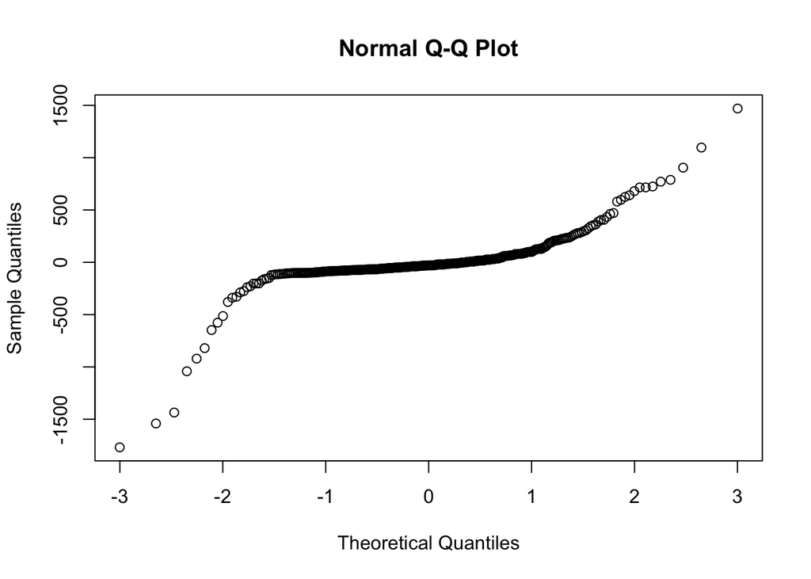

We can see that the homoscedasticity hypothesis is not satisfied. It may be a good idea to consider a Generalized Linear Model of the `poisson` family:

```
##
## Call:
## glm(formula = SalesPrices ~ PriceAtBeginning, family = poisson())
##
## Deviance Residuals:
##     Min       1Q   Median       3Q      Max
## -59.852  -10.329   -0.363    8.279   35.914
##
## Coefficients:
##                   Estimate Std. Error z value Pr(>|z|)
## (Intercept)      6.514e+00  2.186e-03  2979.7   <2e-16 ***
## PriceAtBeginning 4.994e-04  8.729e-07   572.1   <2e-16 ***
## ---
## Signif. codes:  0 '***' 0.001 '**' 0.01 '*' 0.05 '.' 0.1 ' ' 1
##
## (Dispersion parameter for poisson family taken to be 1)
##
##     Null deviance: 319156  on 371  degrees of freedom
## Residual deviance:  67967  on 370  degrees of freedom
## AIC: 71222
##
## Number of Fisher Scoring iterations: 4
```

```
##
##  Overdispersion test
##
## data:  poisson_baseline
## z = 11.611, p-value < 2.2e-16
## alternative hypothesis: true dispersion is greater than 1
## sample estimates:
## dispersion
##   167.1315
```

Since there is overdispersion and high residuals, let’s try the negative binomial model with `log` and `identity` link function.

```
##
## Call:
## glm.nb(formula = SalesPrices ~ PriceAtBeginning, data = Constructions,
##     link = "log", init.theta = 6.576522864)
##
## Deviance Residuals:
##     Min       1Q   Median       3Q      Max
## -4.1931  -0.6292   0.2092   0.5854   1.8047
##
## Coefficients:
##                   Estimate Std. Error z value Pr(>|z|)
## (Intercept)      6.168e+00  3.009e-02  204.97   <2e-16 ***
## PriceAtBeginning 7.478e-04  2.036e-05   36.72   <2e-16 ***
## ---
## Signif. codes:  0 '***' 0.001 '**' 0.01 '*' 0.05 '.' 0.1 ' ' 1
##
## (Dispersion parameter for Negative Binomial(6.5765) family taken to be 1)
##
##     Null deviance: 1619.84  on 371  degrees of freedom
## Residual deviance:  382.35  on 370  degrees of freedom
## AIC: 5519.2
##
## Number of Fisher Scoring iterations: 1
##
##
##               Theta:  6.577
##           Std. Err.:  0.476
##
##  2 x log-likelihood:  -5513.236
```

```
##
## Call:
## glm.nb(formula = SalesPrices ~ PriceAtBeginning, data = Constructions,
##     link = "identity", init.theta = 82.87164337)
##
## Deviance Residuals:
##     Min       1Q   Median       3Q      Max
## -3.6491  -0.5408  -0.1733   0.4434   4.4321
##
## Coefficients:
##                  Estimate Std. Error z value Pr(>|z|)
## (Intercept)      25.31226    4.52318   5.596 2.19e-08 ***
## PriceAtBeginning  1.26787    0.01088 116.527  < 2e-16 ***
## ---
## Signif. codes:  0 '***' 0.001 '**' 0.01 '*' 0.05 '.' 0.1 ' ' 1
##
## (Dispersion parameter for Negative Binomial(82.8716) family taken to be 1)
##
##     Null deviance: 18891.84  on 371  degrees of freedom
## Residual deviance:   375.62  on 370  degrees of freedom
## AIC: 4598.3
##
## Number of Fisher Scoring iterations: 1
##
##
##               Theta:  82.87
##           Std. Err.:  6.71
##
##  2 x log-likelihood:  -4592.276
```

Confronting *Akaike information criterion* (AIC) and Residuals, we can easily choose the negative binomial model with `identity` link function. We also tried other standard generalized linear model (with different link functions) without reporting here: they all performs worse (comparing AIC values) than this. We would like to mention the gamma family with identity as link function: it performs nearly the same. So we decided to consider both models and then choose the best. To find the best features we consider an automatic stepwise algorithm to choose a model by AIC. Since we may avoid some rough collinearity, we decided to feed the algorithm with an upper model containing just some of the $19$ features that are measured through time. With a brief analysis (omitted here for the sake of brevity) we decided to consider just the indexes at the building completion (marked as ‘_5’ in the dataset).

Now let’s build the two best model (with Gamma and Negative Binomial) based on AIC using the stepwise algorithm.

```
##         PriceAtBeginning     ConstructionDuration  CPIFornituresBaseYear_5
##                 2.638643                 1.168060               115.372219
## LandPriceIndexBaseYear_5    CumulativeLiquidity_5 OfficialExcangeRateUSD_5
##                67.541017               148.759508                12.290683
##           InterestRate_5                    BSI_5    LoansExtendedAmount_5
##                 2.390811               218.216537                14.315430
##         CityPopulation_5        LoansExtendedNo_5       StockMarketIndex_5
##                 5.186431                12.920298                13.933498
##   TotEstConstructionCost
##                 1.483118
```

```
##
## Call:
## glm.nb(formula = SalesPrices ~ PriceAtBeginning + ConstructionDuration +
##     CPIFornituresBaseYear_5 + LandPriceIndexBaseYear_5 + CumulativeLiquidity_5 +
##     OfficialExcangeRateUSD_5 + InterestRate_5 + BSI_5 + LoansExtendedAmount_5 +
##     CityPopulation_5 + LoansExtendedNo_5 + StockMarketIndex_5 +
##     TotEstConstructionCost, init.theta = 264.532849, link = "identity")
##
## Deviance Residuals:
##     Min       1Q   Median       3Q      Max
## -4.5701  -0.5040  -0.0163   0.4618   3.4293
##
## Coefficients:
##                            Estimate Std. Error z value Pr(>|z|)
## (Intercept)              -2.698e+02  2.939e+01  -9.180  < 2e-16 ***
## PriceAtBeginning          1.275e+00  1.063e-02 119.976  < 2e-16 ***
## ConstructionDuration      2.259e+01  1.286e+00  17.565  < 2e-16 ***
## CPIFornituresBaseYear_5   8.149e+00  7.568e-01  10.768  < 2e-16 ***
## LandPriceIndexBaseYear_5 -8.699e+00  5.643e-01 -15.415  < 2e-16 ***
## CumulativeLiquidity_5     8.392e-04  1.103e-04   7.607 2.81e-14 ***
## OfficialExcangeRateUSD_5  1.057e-02  3.256e-03   3.246  0.00117 **
## InterestRate_5            1.767e+01  2.428e+00   7.275 3.47e-13 ***
## BSI_5                    -5.939e+00  1.033e+00  -5.750 8.90e-09 ***
## LoansExtendedAmount_5    -2.770e-03  8.773e-04  -3.157  0.00159 **
## CityPopulation_5          1.318e-03  4.103e-04   3.211  0.00132 **
## LoansExtendedNo_5        -2.042e-01  8.746e-02  -2.335  0.01956 *
## StockMarketIndex_5       -5.290e-03  2.748e-03  -1.925  0.05427 .
## TotEstConstructionCost    2.058e-02  1.205e-02   1.709  0.08752 .
## ---
## Signif. codes:  0 '***' 0.001 '**' 0.01 '*' 0.05 '.' 0.1 ' ' 1
##
## (Dispersion parameter for Negative Binomial(264.5328) family taken to be 1)
##
##     Null deviance: 51861.83  on 371  degrees of freedom
## Residual deviance:   346.42  on 358  degrees of freedom
## AIC: 4230.4
##
## Number of Fisher Scoring iterations: 1
##
##
##               Theta:  264.5
##           Std. Err.:  23.3
##
##  2 x log-likelihood:  -4200.443
```

A future improvement can be done eliminating collinearity to comprehend the real impact of each feature.

Let’s make the same work with the gamma family and just see the results.

```
##
## Call:
## glm(formula = SalesPrices ~ PriceAtBeginning + ConstructionDuration +
##     CPIFornituresBaseYear_5 + LandPriceIndexBaseYear_5 + OfficialExcangeRateUSD_5 +
##     GoldPriceOnce_5 + CPIBaseYear_5 + CompletionYear + CumulativeLiquidity_5 +
##     LoansExtendedNo_5 + BSI_5 + CityPopulation_5 + WPI_5 + InterestRate_5 +
##     factor(BuildingZIPCode) + TotEstConstructionCost, family = Gamma(link = "identity"))
##
## Deviance Residuals:
##       Min         1Q     Median         3Q        Max
## -0.300743  -0.035750  -0.000478   0.028436   0.244076
##
## Coefficients:
##                             Estimate Std. Error t value Pr(>|t|)
## (Intercept)               -4.046e+04  1.026e+04  -3.945 9.64e-05 ***
## PriceAtBeginning           1.271e+00  1.117e-02 113.834  < 2e-16 ***
## ConstructionDuration       1.204e+01  2.216e+00   5.434 1.03e-07 ***
## CPIFornituresBaseYear_5    7.965e+00  1.460e+00   5.458 9.11e-08 ***
## LandPriceIndexBaseYear_5  -6.995e+00  5.484e-01 -12.755  < 2e-16 ***
## OfficialExcangeRateUSD_5   9.688e-03  2.417e-03   4.009 7.45e-05 ***
## GoldPriceOnce_5            1.489e-04  4.542e-05   3.279 0.001147 **
## CPIBaseYear_5             -4.279e+00  1.827e+00  -2.341 0.019765 *
## CompletionYear             2.940e+01  7.489e+00   3.926 0.000104 ***
## CumulativeLiquidity_5      5.388e-04  1.016e-04   5.304 2.01e-07 ***
## LoansExtendedNo_5         -3.098e-01  6.349e-02  -4.879 1.62e-06 ***
## BSI_5                     -3.968e+00  1.087e+00  -3.651 0.000301 ***
## CityPopulation_5           1.078e-03  3.379e-04   3.190 0.001549 **
## WPI_5                     -2.939e+00  1.269e+00  -2.315 0.021181 *
## InterestRate_5             6.754e+00  3.004e+00   2.249 0.025158 *
## factor(BuildingZIPCode)3   2.469e+00  1.617e+01   0.153 0.878723
## factor(BuildingZIPCode)6   4.359e+01  2.061e+01   2.115 0.035128 *
## factor(BuildingZIPCode)21 -1.152e+00  1.100e+01  -0.105 0.916682
## TotEstConstructionCost     1.690e-02  1.168e-02   1.447 0.148671
## ---
## Signif. codes:  0 '***' 0.001 '**' 0.01 '*' 0.05 '.' 0.1 ' ' 1
##
## (Dispersion parameter for Gamma family taken to be 0.004488122)
##
##     Null deviance: 248.1149  on 371  degrees of freedom
## Residual deviance:   1.5897  on 353  degrees of freedom
## AIC: 4201.5
##
## Number of Fisher Scoring iterations: 6
```

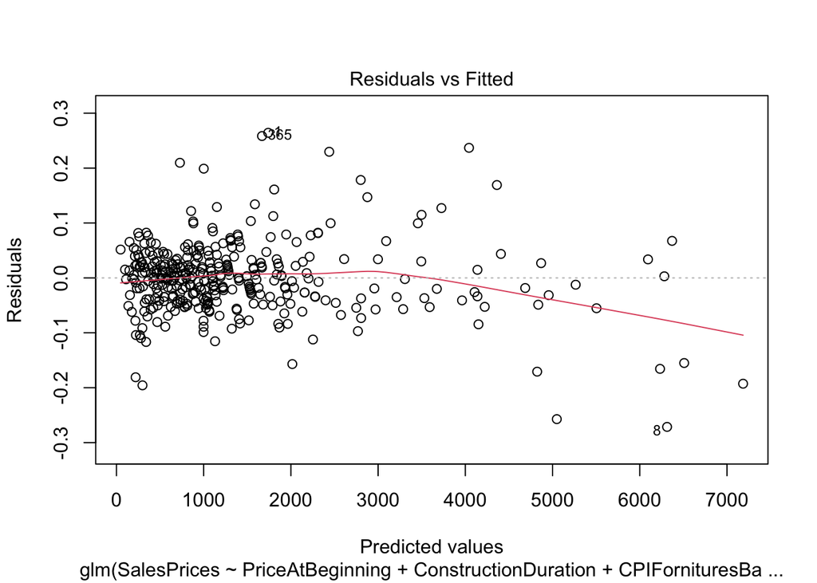

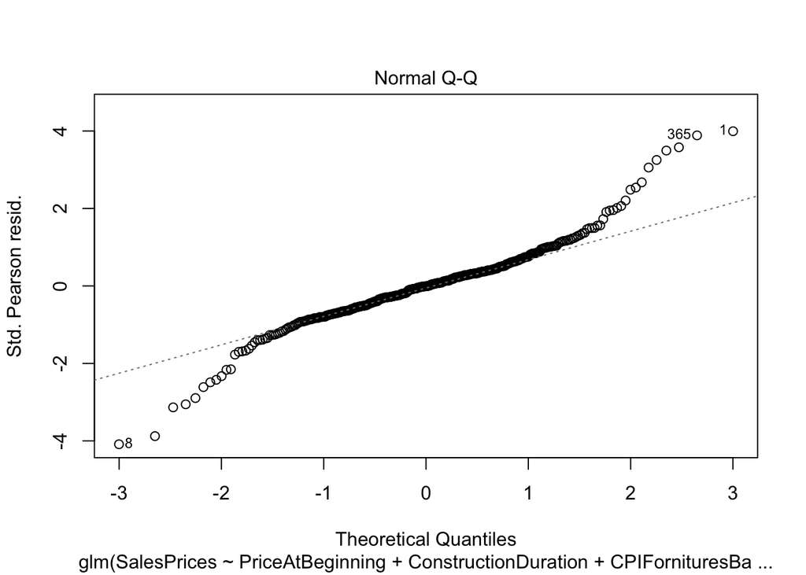

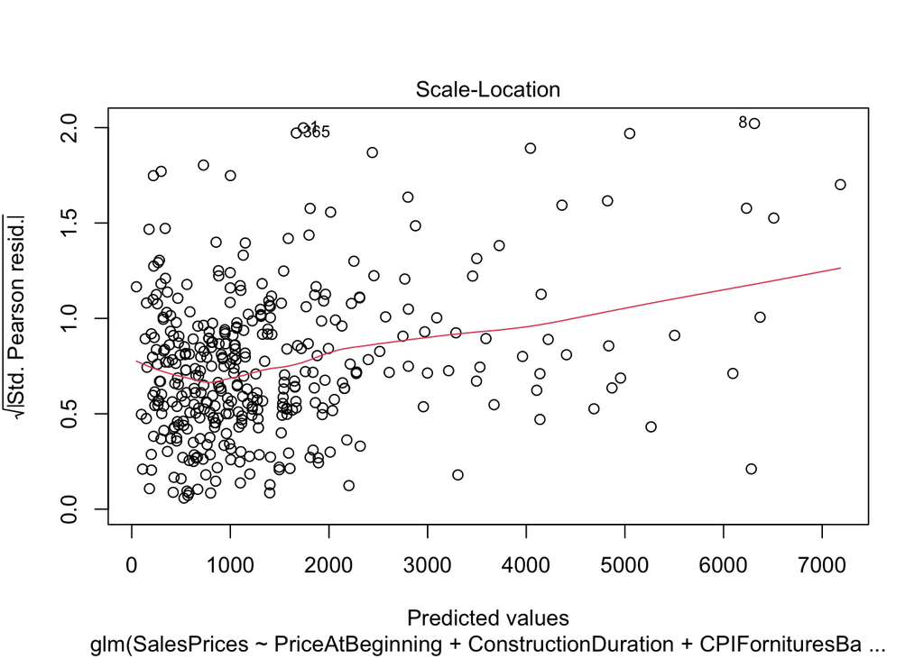

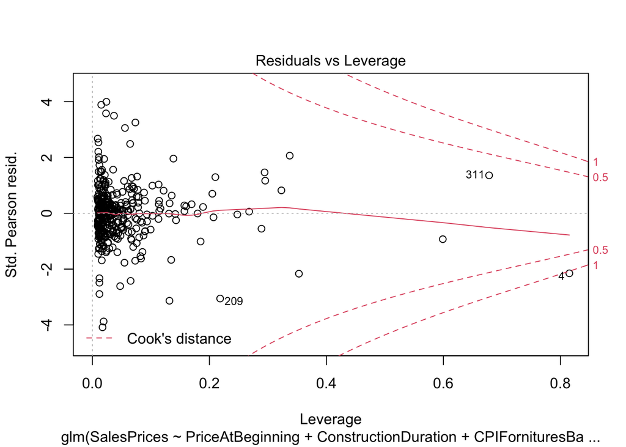

By confronting AIC values, we can easily say that the best model is the gamma with identity link function.

At cost of interpretability, we can also build the model using all the environment indexes and see if the model improves.

```
##
## Call:
## glm(formula = SalesPrices ~ PriceAtBeginning + ConstructionDuration +
##     PrivateSectorInvestment_5 + LoansExtendedAmount_3 + PrivateSectorInvestment_4 +
##     LoansExtendedNo_1 + LandPriceIndexBaseYear_4 + GoldPriceOnce_1 +
##     CumulativeLiquidity_1 + OfficialExcangeRateUSD_5 + BuildingPermitsNo_4 +
##     ConstructionCostAtBeginning_1 + InterestRate_3 + LandPriceIndexBaseYear_3 +
##     ConstructionCostAtCompletion_2 + CPIFornituresBaseYear_1 +
##     WPI_2 + BuildingZIPCode + EstConstructionCost + CPIBaseYear_2 +
##     StreetMarketExcangeRateUSD_1 + StreetMarketExcangeRateUSD_4 +
##     CPIFornituresBaseYear_3, family = Gamma(link = "identity"))
##
## Deviance Residuals:
##       Min         1Q     Median         3Q        Max
## -0.217708  -0.028042  -0.000518   0.025854   0.224742
##
## Coefficients:
##                                  Estimate Std. Error t value Pr(>|t|)
## (Intercept)                    -1.845e+02  3.748e+01  -4.922 1.33e-06 ***
## PriceAtBeginning                1.265e+00  1.162e-02 108.799  < 2e-16 ***
## ConstructionDuration            2.008e+01  9.974e-01  20.132  < 2e-16 ***
## PrivateSectorInvestment_5      -9.651e-03  4.833e-03  -1.997 0.046620 *
## LoansExtendedAmount_3           2.653e-03  7.198e-04   3.686 0.000265 ***
## PrivateSectorInvestment_4      -1.120e-02  6.351e-03  -1.763 0.078821 .
## LoansExtendedNo_1               1.421e-01  3.629e-02   3.916 0.000108 ***
## LandPriceIndexBaseYear_4       -9.333e+00  9.145e-01 -10.205  < 2e-16 ***
## GoldPriceOnce_1                 1.442e-04  3.933e-05   3.666 0.000285 ***
## CumulativeLiquidity_1           1.341e-04  9.219e-05   1.455 0.146669
## OfficialExcangeRateUSD_5        8.541e-03  3.372e-03   2.533 0.011757 *
## BuildingPermitsNo_4             9.842e-03  3.268e-03   3.012 0.002790 **
## ConstructionCostAtBeginning_1  -8.855e-02  2.335e-02  -3.793 0.000176 ***
## InterestRate_3                  8.580e+00  2.956e+00   2.903 0.003933 **
## LandPriceIndexBaseYear_3        3.621e+00  8.033e-01   4.508 8.97e-06 ***
## ConstructionCostAtCompletion_2 -1.016e-01  2.432e-02  -4.176 3.75e-05 ***
## CPIFornituresBaseYear_1         6.037e+00  2.259e+00   2.672 0.007897 **
## WPI_2                          -3.763e+00  8.444e-01  -4.456 1.13e-05 ***
## BuildingZIPCode3               -2.734e-01  1.443e+01  -0.019 0.984898
## BuildingZIPCode6                4.629e+01  1.833e+01   2.525 0.012018 *
## BuildingZIPCode21              -1.515e+00  9.851e+00  -0.154 0.877888
## EstConstructionCost             1.421e-01  6.711e-02   2.118 0.034902 *
## CPIBaseYear_2                   7.185e+00  1.797e+00   3.997 7.84e-05 ***
## StreetMarketExcangeRateUSD_1   -1.344e-02  4.256e-03  -3.158 0.001728 **
## StreetMarketExcangeRateUSD_4   -7.824e-03  3.851e-03  -2.031 0.042969 *
## CPIFornituresBaseYear_3        -4.139e+00  1.885e+00  -2.196 0.028751 *
## ---
## Signif. codes:  0 '***' 0.001 '**' 0.01 '*' 0.05 '.' 0.1 ' ' 1
##
## (Dispersion parameter for Gamma family taken to be 0.003569509)
##
##     Null deviance: 248.1149  on 371  degrees of freedom
## Residual deviance:   1.2275  on 346  degrees of freedom
## AIC: 4119.2
##
## Number of Fisher Scoring iterations: 5
```

The resulting model is really complex but better in predicting. We perform a 10-cross validation to assess our models estimating the MSE errors (and checking if over-fitting occurs).

```r
#MSE and MSE adjusted
set.seed(234)
#cv.glm(Constructions, fit_best_NegBin, K=10)$delta #NegBin
#cv.glm(Constructions, fit_best_Gamma,K=10)$delta #Gamma
#cv.glm(Constructions, fit_best_Gamma_all, K=10)$delta #Gamma_all

#mean((SalesPrices-predict(fit_best_Gamma_all))^2) #Gamma_all on the dataset

print(c(
  NegBin=cv.glm(Constructions, fit_best_NegBin, K=10)$delta[1],
  Gamma=cv.glm(Constructions, fit_best_Gamma, K=10)$delta[1],
  Gamma_all=cv.glm(Constructions, fit_best_Gamma_all, K=10)$delta[1],
  Gamma_all_dataset=mean((SalesPrices-predict(fit_best_Gamma_all))^2)
  ))
```

```
##            NegBin             Gamma         Gamma_all Gamma_all_dataset
##          39845.29          41393.10          33593.89          30703.44
```

We obtain that the last model (gamma with all features) is a bit overfitting the data, but it is still performing better. Let’s also compare them with a random forest model (keeping all the features).

```
## [1] "MSE:"             "82319.1166324992"
```

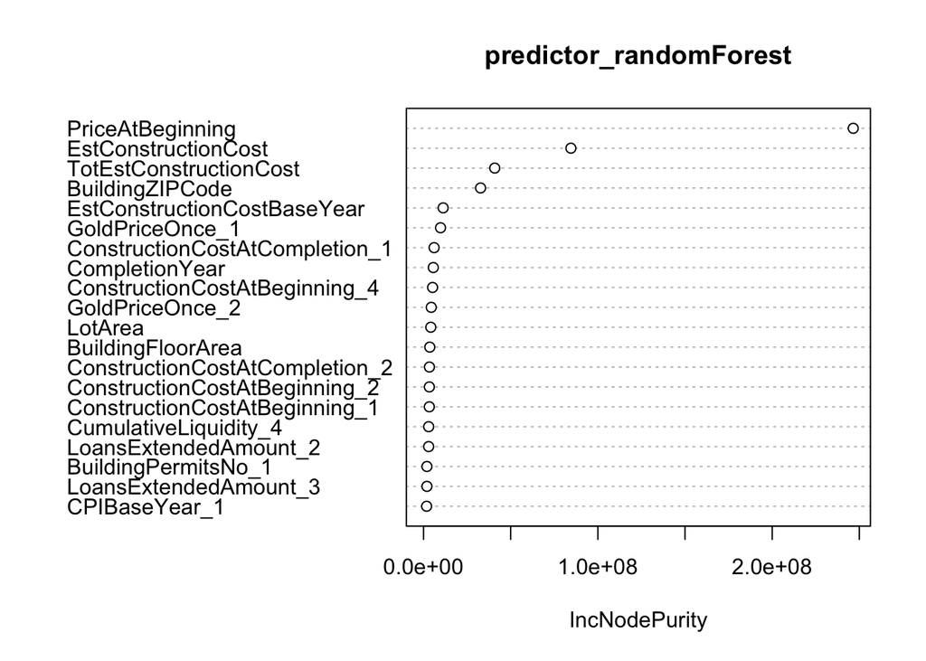

We can see that the MSE error is way bigger than the last one. A brief look at the variable importance plot may be informative.

## Conclusions

At the beginning of the data analysis we used as a base model the linear model with the predictor variable `PriceAtBeginning`. We choose this variable because in the study of the correlation between the response variable and the predictor variables, `PriceAtBeginning` is the predictor variable with the highest positive correlation value ($0.976$). Then we saw that the hypothesis of homoscedasticity was not fulfilled, we decided to consider the Poisson model (which fails because it has overdispersion), the negative binomial with log link function, and the negative binomial model with identity link function, since they are the most appropriate for our response variable.

From the study conducted on the correlation between the response variable and the predictor variables we can also highlight that the highest negative value ($-0.435$) corresponds to the variable `BuildingZIPCode`, this means that the selling price of the buildings is higher when the ZIP Codes is lower. So as some ZIP codes are more influential than others, we decided to group them into 4 different groups.

After a simple comparison of the *Akaike Information Criterion* values, we choose the negative binomial model with the identity link function as it has the lowest AIC value. We proceeded to compare this model with a gamma model with identity link function as they are similar.

To avoid collinearity and after a brief analysis, we consider a new model whose variables are:

- of the 19 characteristics that are measured over time, those that measure the period of building completion;
- The transformation of the `BuildingZIPCode` variable, in which we divided the original ZIP codes into four main groups.

In this way, we constructed the two best-fitting models and compared them:

In the case of the negative binomial model, when checking the collinearity we see that there are variables with high VIF values and therefore the model could be improved by eliminating the collinearity. When building these model, if we focus on the variables with low VIF value (less than 5), such as `ConstructionDuration` or `InteresRate_5`, and look at their p-values, we can see that these predictor variables are statistically significant at the $0.05$ significance level and thus would be quite fundamental for a good fit. The only exception is the variable `TotEstConstructionCost`that has a low VIF but its p-value is not significance at $0.05$ level.

After developing the models and comparing the AIC values, we conclude that the best model is the gamma model with the identity link function.

Finally, to make sure we made the best choice, we compared the model we were working with (whose predictor variables were modified) with the gamma model with all the original variables (all the environmental indices) and for this model we obtained a lower AIC value, therefore it is better.

Through the 10-cross validation and comparing by mean squared error the three models, we obtained again that the lowest RMSE values are those of the gamma model with all variables. Even when comparing this model with a Random Forest (using all features), we see that, indeed, the forest model has a higher MSE error.

Therefore, to estimate the `SalesPrices` variable in this dataset, the most appropriate model is the gamma model including all explanatory variables that comes from the output of the stepwise algorithm, that tests all the possible ones.

[^1]: The number of *time resolutions* before the start of the project.